# Estudio sobre infectados de coronavirus

## Planteamiento y modelado del problema

## Introducción

En estos días está como noticia estrella la pandemía por **coronavirus** que estamos sufriendo prácticamente todos los humanos que habitan nuestro planeta.

Una de las preguntas que nos podemos hacer es si la **pandemía** se **expande** igual por todo el mundo, o, por el contrario, hay lugares donde la **expansión** es distinta de los demás.

Seguidamente vamos a modelar el problema.

## Modelado del problema

En primer lugar, fijamos una fecha determinada donde el **coronavirus** ya se ha expandido.

Para dicha fecha, sea \(N\) el número de personas que han estado expuestas al **coronavirus** dicho día y \(I\) el número total de infectados en dicho día.

Por último, sea \(X\) la variable aleatoria que nos da el número de infectados este día determinado. La distribución de \(X\), aunque es desconocida, es independiente del lugar y de la persona.

Nuestro objetivo será, pues, usar el **test estadístico** más adecuado para contrastar la independencia de la distribución de \(X\) del lugar y de la persona.

## Modelado del problema

El **test estadístico** más adecuado para llevar a cabo dicho contraste es el **test \(\chi^2\)** o **test de bondad de ajuste**.

Para poder usar dicho test, necesitamos establecer unas **clases** que serán donde tendremos que calcular las **frecuencias empíricas** de infectados y las correspondientes **frecuencias teóricas**.

Las **clases** a considerar serán los países en los que se ha expandido el **coronavirus** el día en cuestión: \(P_1,\ldots,P_n\), donde \(n\) es el número total de países a estudiar.

## Modelado del problema

Las **frecuencias empíricas** de cada país \(P_i\), \(n_i\), será el número de infectados del país \(P_i\) el día en cuestión.

Sea \(H_i\) el número total de habitantes del país \(P_i\) o la población del mismo.

Si la expansión del **coronavirus** no depende del país ni de la persona, el **número de infectados esperado** para el país \(P_i\) o la **frecuencia esperada o teórica** de dicho país será: \[ e_i=\frac{H_i}{N}\cdot I. \]

## Test \(\chi^2\)

Tendremos por tanto una tabla como la detallada a continuación:

| Pais | Infectados reales | Infectados estimados |
| --- | --- | --- |
| \(P_1\) | \(n_1\) | \(e_1\) |
| \(P_2\) | \(n_2\) | \(e_2\) |
| \(\vdots\) | \(\vdots\) | \(\vdots\) |
| \(P_n\) | \(n_n\) | \(e_n\) |

donde \(I=n_1+\cdots +n_n=e_1+\cdots +e_n\).

## Test \(\chi^2\)

El test \(\chi^2\) consiste en hallar el siguiente **estadístico de contraste** \[ \chi^2 = \sum_{i=1}^n \frac{(n_i-e_i)^2}{e_i}, \] que si la **hipótesis nula** es cierta donde recordemos que nuestra **hipótesis nula** era que el **coronavirus** se infectaba aleatoriamente por igual en todos los países, se distribuye según una variable \(\chi^2_{n-1}\)

## Test \(\chi^2\)

El **p-valor** del contraste anterior será: \[ p = p(\chi^2_{n-1}>\chi^2). \] Si el \(p\) anterior es muy pequeño, concluiremos que tenemos evidencias suficientes para **rechazar** la hipótesis nula y decir que el virus no se **expande** de la misma manera por todos los países.

## Resolución en `R`

## Tabla de datos

Para realizar el estudio anterior, usaremos la tabla de datos `covid19`.

Vamos a cargarla:

```r
covid19=read.csv("covid_19_clean_complete.csv")
```

## Tabla de datos

Hagamos un pequeño resumen de las variables de dicha tabla de datos:

```r
str(covid19)
```

```
## 'data.frame':    21484 obs. of  8 variables:
##  $ Province.State: Factor w/ 81 levels "","Alberta","Anguilla",..: 1 1 1 1 1 1 1 1 6 49 ...
##  $ Country.Region: Factor w/ 185 levels "Afghanistan",..: 1 2 3 4 5 6 7 8 9 9 ...
##  $ Lat           : num  33 41.2 28 42.5 -11.2 ...
##  $ Long          : num  65 20.17 1.66 1.52 17.87 ...
##  $ Date          : Factor w/ 82 levels "1/22/20","1/23/20",..: 1 1 1 1 1 1 1 1 1 1 ...
##  $ Confirmed     : int  0 0 0 0 0 0 0 0 0 0 ...
##  $ Deaths        : int  0 0 0 0 0 0 0 0 0 0 ...
##  $ Recovered     : int  0 0 0 0 0 0 0 0 0 0 ...
```

## Tabla de datos

Como vemos, es una tabla de datos con 8 variables:

- `Province.State`: nos indica la provincia o el estado del país en cuestión.
- `Country.Region`: nos dice el país donde están los datos.
- `Lat`: nos da la latitud del pais.
- `Long`: nos da la longitud del pais.
- `Date`: nos dice la fecha en la que han sido tomados los datos.
- `Confirmed`: nos da el número de infectados en una determinada región de un país determinado en una fecha determinada.
- `Death`: lo mismo que la variable anterior pero nos da el número de víctimas.
- `Recovered`: lo mismo que la variable anterior pero nos da el número de recuperados.

## Número de habitantes por países

Para calcular el número de habitantes por países vamos a usar la función `wb` del paquete `wbstats`:

```r
library(wbstats)
pop_data <- wb(indicator = "SP.POP.TOTL", startdate = 2018, enddate = 2019)
```

Como podemos ver, hemos cargado el paquete y, a partir de la función anterior le hemos dicho que nos dé el número de habitantes por países desde 2018 hasta 2019 (aún no se dispone de datos del año actual 2020)

## Número de habitantes por países

Veamos a modo de ejemplo el número de habitantes de España, Italia y Francia:

```r
pop_data[pop_data$country=="Spain",]
```

```
##     iso3c date    value indicatorID         indicator iso2c country
## 454   ESP 2018 46796540 SP.POP.TOTL Population, total    ES   Spain
```

```r
pop_data[pop_data$country=="Italy",]
```

```
##     iso3c date    value indicatorID         indicator iso2c country
## 288   ITA 2018 60421760 SP.POP.TOTL Population, total    IT   Italy
```

```r
pop_data[pop_data$country=="France",]
```

```
##     iso3c date    value indicatorID         indicator iso2c country
## 232   FRA 2018 66977107 SP.POP.TOTL Population, total    FR  France
```

## Limpieza de la tabla de datos

El siguiente paso es “limpiar” la tabla de datos `cov19` eliminando todos aquellos paises de los que no tenemos datos:

```r
paises=unique(covid19$Country.Region)
covid19.limpio =c()
for (i in 1:length(paises)){
  if(length(which(paises[i] %in% pop_data$country))>0){
    covid19.limpio = rbind(covid19.limpio,covid19[covid19$Country.Region==paises[i],])
  }
}
```

## Limpieza de la tabla de datos

Como podemos observar en el vector `paises` hemos colocado todos los paises de la tabla de datos `cov19` y para cada país, comprobamos si sus datos están en la tabla de datos `pop_data` y si están, lo añadimos a la nueva tabla de datos `covid19.limpio`.

En total, teníamos al principio en la tabla de datos original `covid19` 21484 filas de los que han “sobrevivido” 19270 filas.

## Gráfico de los infectados, fallecidos y recuperados totales

Antes de realizar el **test de bondad de ajuste** o **test de la \(\chi^2\)** hagamos un gráfico del total de infectados, fallecidos y recuperados totales para todos los días especificados en nuestra tabla de datos.

Primero calculamos los infectados, fallecidos y recuperados totales usando la función `aggregate`:

## Gráfico de los infectados, fallecidos y recuperados totales

```r
covid19.limpio$Date=as.Date(as.character(covid19.limpio$Date),"%m/%d/%Y")
infectados.totales.por.dia = aggregate(covid19.limpio$Confirmed ~
                    covid19.limpio$Date,FUN=sum)
fallecidos.totales.por.dia = aggregate(covid19.limpio$Deaths ~
                    covid19.limpio$Date,FUN=sum)
recuperados.totales.por.dia = aggregate(covid19.limpio$Recovered ~
                    covid19.limpio$Date,FUN=sum)
tabla.totales = data.frame(infectados.totales.por.dia[,1],infectados.totales.por.dia[,2],
              fallecidos.totales.por.dia[,2],recuperados.totales.por.dia[,2])
names(tabla.totales) = c("Fecha", "Infectados", "Fallecidos", "Recuperados")
```

## Gráfico de los infectados, fallecidos y recuperados totales

Veamos la tabla anterior para los 10 primeros días:

```r
head(tabla.totales,10)
```

```
##         Fecha Infectados Fallecidos Recuperados
## 1  0020-01-22        552         17          28
## 2  0020-01-23        651         18          30
## 3  0020-01-24        934         26          36
## 4  0020-01-25       1427         42          39
## 5  0020-01-26       2106         56          52
## 6  0020-01-27       2913         82          61
## 7  0020-01-28       5561        131         107
## 8  0020-01-29       6149        133         126
## 9  0020-01-30       8216        171         143
## 10 0020-01-31       9897        213         222
```

## Gráfico de los infectados, fallecidos y recuperados totales

El gráfico será el siguiente:

```r
library(ggplot2)
x=tabla.totales[,1]
ggplot(tabla.totales, aes(x)) +
  geom_line(aes(y=tabla.totales$Infectados, colour="Infectados")) +
  geom_line(aes(y=tabla.totales$Fallecidos, colour="Fallecidos")) +
  geom_line(aes(y=tabla.totales$Recuperados, colour="Recuperados")) +
  xlab("Fecha") + ylab("Frecuencias") +
  scale_color_manual(values=c("red", "blue", "green"))
```

## Gráfico de los infectados, fallecidos y recuperados totales

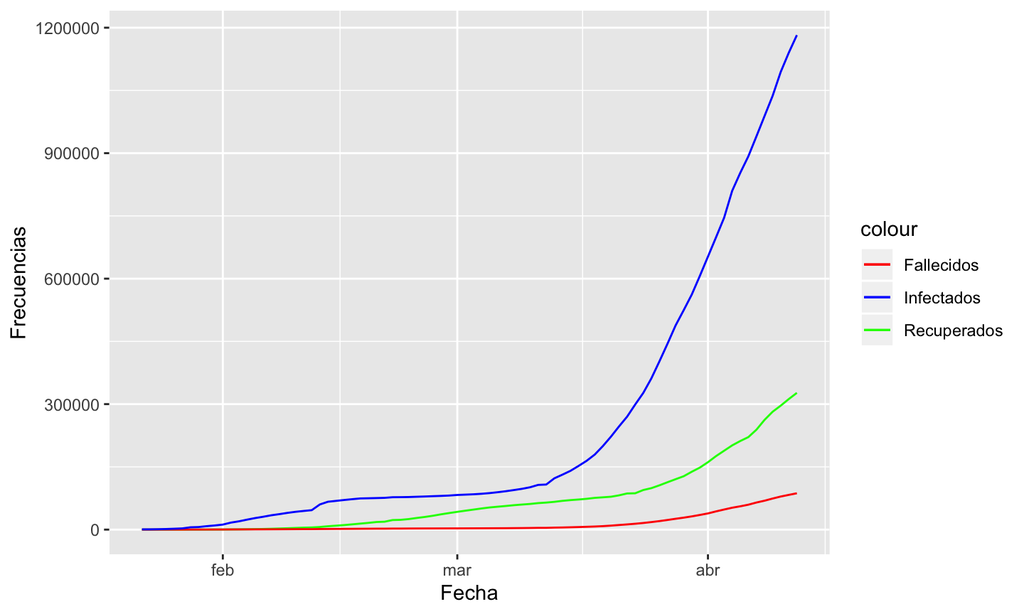

## Cálculo de las frecuencias empíricas \(n_i\) para cada país

En primer lugar, fijamos una fecha para realizar nuestro estudio:

```r
fecha="0020-03-15"
```

Fijémonos que primero está el año, luego el mes y, para finalizar, el día. Por tanto, nuestro estudio es para el día 15 de marzo del año actual 2020.

El número de casos confirmados \(n_i\) por país se calcula con la función `aggregate`:

```r
confirmados.por.pais = aggregate(covid19.limpio$Confirmed[covid19.limpio$Date==fecha] ~
                    covid19.limpio$Country.Region[covid19.limpio$Date==fecha],FUN=sum)
names(confirmados.por.pais)=c("Pais","Confirmados")
```

## Cálculo de las frecuencias empíricas \(n_i\) para cada país

Los confirmados de los 10 primeros países serán:

```r
head(confirmados.por.pais,10)
```

```
##                   Pais Confirmados
## 1          Afghanistan          16
## 2              Albania          42
## 3              Algeria          48
## 4              Andorra           1
## 5               Angola           0
## 6  Antigua and Barbuda           1
## 7            Argentina          45
## 8              Armenia          26
## 9            Australia         297
## 10             Austria         860
```

## Cálculo del número total de infectados \(I\)

El número total de expuestos \(N\) y el número total de infectados \(I\) se calcula de la forma siguiente:

```r
paises=unique(covid19.limpio$Country.Region)
suma.total.habitantes=sum(pop_data[pop_data$country %in% paises,]$value)
número.total.infectados = sum(confirmados.por.pais$Confirmados)
```

## Cálculo del número total de infectados \(I\)

Como podemos observar, volvemos a calcular los países con la tabla de datos limpia `covid19.limpio`, a continuación calculamos el número total de habitantes \(N\) del estudio sumando la variable `value` de la tabla de datos `pop_data` para los paises en cuestión. Por último, calculamos el número total de infectados \(I\) sumando los valores de la variable `Confirmed` de la tabla de datos `covid19.limpio`.

## Cálculo de las frecuencias esperadas \(e_i\) para cada pais

Recordemos que el **número de infectados esperado** para el pais \(P_i\) era: \(e_i =\frac{H_i}{N}\cdot I\), donde \(H_i\), el número de habitantes de cada pais, ya lo tenemos en la tabla de datos `pop_data`, \(N\), el número de habitantes total, ya lo hemos calculado antes en la variable `suma.total.habitantes` y \(I\) ya está estimado en la variable `número.total.infectados`.

## Cálculo de las frecuencias esperadas \(e_i\) para cada pais

Para calcular las frecuencias esperadas \(e_i\) para cada pais, vamos a crear una tabla llamada `tabla.infectados.paises` que tendrá tres columnas:

- `pais`: donde habrá el nombre del país en cuestión.
- `infectados`: donde habrá los infectados reales \(n_i\) de cada país.
- `estimados`: donde habrá los infectados estimados \(e_i\) de cada país.

## Cálculo de las frecuencias esperadas \(e_i\) para cada pais

```r
tabla.infectados.paises =c()

for (i in 1:length(paises)){
    habitantes=pop_data[pop_data$country==paises[i],]$value
    confirmados = confirmados.por.pais$Confirmados[confirmados.por.pais$Pais==paises[i]]
    confirmados.estimados = número.total.infectados*habitantes/suma.total.habitantes
    tabla.infectados.paises=rbind(tabla.infectados.paises,
                                  c(confirmados,confirmados.estimados))
}
tabla.infectados.paises=as.data.frame(tabla.infectados.paises)
tabla.infectados.paises = data.frame(paises,tabla.infectados.paises)
names(tabla.infectados.paises)=c("pais","infectados","infectados.estimados")
```

## Test \(\chi^2\)

A continuación realizamos el test de la \(\chi^2\):

```r
chisq.test(tabla.infectados.paises$infectados,
  p=tabla.infectados.paises$infectados.estimados/sum(tabla.infectados.paises$infectados))
```

```
##
##  Chi-squared test for given probabilities
##
## data:  tabla.infectados.paises$infectados
## X-squared = 735730, df = 157, p-value < 2.2e-16
```

## Test \(\chi^2\)

¡Ups! Tenemos problemas, parece que hay países donde sus frecuencias esperadas de infectados \(e_i\) no llegan a 5. Veamos qué paises son:

```r
paises.con.problemas = which(tabla.infectados.paises$infectados.estimados < 5)
paises[paises.con.problemas]
```

```
## [1] Andorra               Antigua and Barbuda   Liechtenstein
## [4] Monaco                San Marino            Seychelles
## [7] Dominica              Grenada               Sao Tome and Principe
## 185 Levels: Afghanistan Albania Algeria Andorra ... Zimbabwe
```

## Test \(\chi^2\)

Vamos a juntarlos en un sólo país y volver a aplicar el test de la \(\chi^2\). Primero los quitamos:

```r
tabla.infectados.paises2 = tabla.infectados.paises[-paises.con.problemas,]
```

A continuación sumamos el número total de infectados y de infectados esperados para estos países:

```r
pais.añadir = data.frame("problemas",sum(tabla.infectados.paises[
  tabla.infectados.paises$pais%in% paises[paises.con.problemas],]
  $infectados),sum(tabla.infectados.paises[tabla.infectados.paises$
  pais %in% paises[paises.con.problemas],]$infectados.estimados))
names(pais.añadir)=names(tabla.infectados.paises2)
pais.añadir
```

```
##        pais infectados infectados.estimados
## 1 problemas        111             16.60782
```

## Test \(\chi^2\)

Comprobamos que la frecuencia esperada de infectados de la suma de todos ya supera 5.

Añadimos el “nuevo pais” y volvemos a realizar el test de la \(\chi^2\):

```r
tabla.infectados.paises2 = rbind(tabla.infectados.paises2,pais.añadir)

chisq.test(tabla.infectados.paises2$infectados,
  p=tabla.infectados.paises2$infectados.estimados/sum(tabla.infectados.paises2$infectados))
```

```
##
##  Chi-squared test for given probabilities
##
## data:  tabla.infectados.paises2$infectados
## X-squared = 722363, df = 149, p-value < 2.2e-16
```

## Conclusión

Vemos que el p-valor es muy pequeño por lo que concluimos que el virus no se expandió por igual en todos los países el día 15 de marzo tal como era de esperar.

## Estudio el día 30 de marzo

Realizemos todo el estudio anterior pero ahora cambiando de fecha. Veamos si el virus se expandió por igual en todos los países el día 30 de marzo:

```r
fecha="0020-03-30"
confirmados.por.pais = aggregate(covid19.limpio$Confirmed[covid19.limpio$Date==fecha] ~
                    covid19.limpio$Country.Region[covid19.limpio$Date==fecha],FUN=sum)
names(confirmados.por.pais)=c("Pais","Confirmados")
número.total.infectados = sum(covid19.limpio[covid19.limpio$Date==fecha,]$Confirmed)
```

## Estudio el día 30 de marzo

```r
tabla.infectados.paises =c()

for (i in 1:length(paises)){
    habitantes=pop_data[pop_data$country==paises[i],]$value
    confirmados = confirmados.por.pais$Confirmados[confirmados.por.pais$Pais==paises[i]]
    confirmados.estimados = número.total.infectados*habitantes/suma.total.habitantes
    tabla.infectados.paises=rbind(tabla.infectados.paises,
                                  c(confirmados,confirmados.estimados))
}
tabla.infectados.paises=as.data.frame(tabla.infectados.paises)
tabla.infectados.paises = data.frame(paises,tabla.infectados.paises)
names(tabla.infectados.paises)=c("pais","infectados","infectados.estimados")
```

## Estudio el día 30 de marzo

```r
paises.con.problemas = which(tabla.infectados.paises$infectados.estimados < 5)
tabla.infectados.paises2 = tabla.infectados.paises[-paises.con.problemas,]
pais.añadir = data.frame("problemas",sum(tabla.infectados.paises[
  tabla.infectados.paises$pais%in% paises[paises.con.problemas],]
  $infectados),sum(tabla.infectados.paises[tabla.infectados.paises$
  pais %in% paises[paises.con.problemas],]$infectados.estimados))
names(pais.añadir)=names(tabla.infectados.paises2)
tabla.infectados.paises2 = rbind(tabla.infectados.paises2,pais.añadir)

chisq.test(tabla.infectados.paises2$infectados,
  p=tabla.infectados.paises2$infectados.estimados/sum(tabla.infectados.paises2$infectados))
```

```
##
##  Chi-squared test for given probabilities
##
## data:  tabla.infectados.paises2$infectados
## X-squared = 5617599, df = 155, p-value < 2.2e-16
```

## Conclusiones

La conclusión es la misma que para la fecha del 15 de marzo: concluimos que tenemos indicios suficientes para afirmar que el virus no se expandió de la misma manera en todos los países.